# R Notebook

```r
library(TSA)
library(tseries)
data("usd.hkd")
forex = usd.hkd$hkrate
library(forecast)
arma21 = Arima(forex, order = c(2,0,1))
arma21
```

```
Series: forex
ARIMA(2,0,1) with non-zero mean

Coefficients:
         ar1      ar2      ma1    mean
      0.2899  -0.0588  -0.4763  -5e-04
s.e.  0.1999   0.0657   0.1957   9e-04

sigma^2 = 0.0007217:  log likelihood = 949.32
AIC=-1888.64   AICc=-1888.5   BIC=-1868.31
```

```r
forecast(arma21, h = 5)
```

|  | Point Forecast | Lo 80 | Hi 80 | Lo 95 | Hi 95 |
| --- | --- | --- | --- | --- | --- |
| 432 | -0.0031248509 | -0.03755278 | 0.03130308 | -0.05577783 | 0.04952813 |
| 433 | -0.0020385201 | -0.03705940 | 0.03298236 | -0.05559834 | 0.05152130 |
| 434 | -0.0007823167 | -0.03601792 | 0.03445329 | -0.05467052 | 0.05310589 |
| 435 | -0.0004820294 | -0.03572558 | 0.03476153 | -0.05438239 | 0.05341834 |
| 436 | -0.0004688276 | -0.03571238 | 0.03477473 | -0.05436920 | 0.05343154 |

Gives the point forecast and confidence intervals

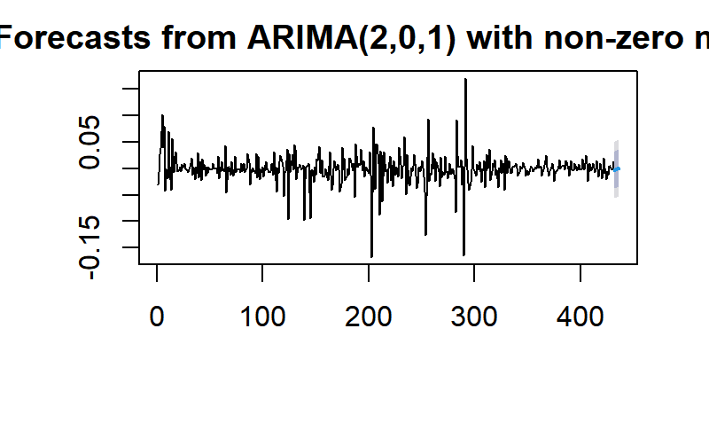

```r
plot(forecast(arma21, h = 5))
```

[figure not shown]

```r
tsdiag(arma21)
```

The residuals should be uncorrelated. The ACF should be zero for h > 0. In this example, the residuals are not correlated.

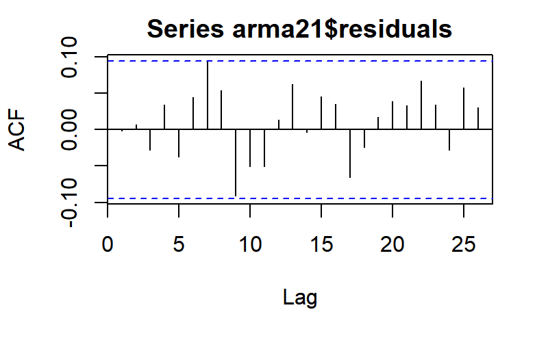

```r
acf(arma21$residuals)
```

```r
jarque.bera.test(residuals(arma21))
```

```
    Jarque Bera Test

data:  residuals(arma21)
X-squared = 2289.7, df = 2, p-value < 2.2e-16
```

```r
library(itsmr)
```

```r
strikes
```

```
 [1] 4737 5117 5091 3468 4320 3825 3673 3694 3708 3333
[11] 3367 3614 3362 3655 3963 4405 4595 5045 5700 5716
[21] 5138 5010 5353 6074 5031 5648 5506 4230 4827 3885
```

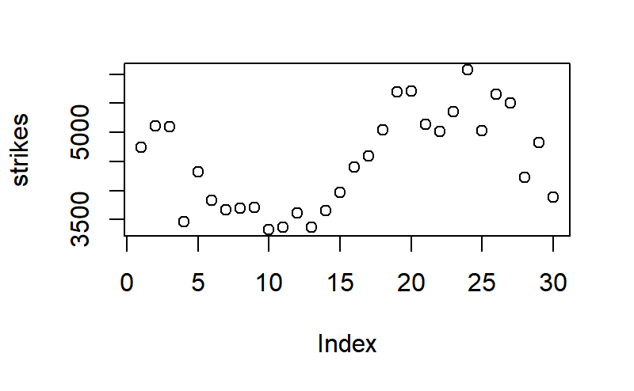

```r
plot(strikes)
```

Since the values are large, we log transform.

```r
strikes.log = log(strikes)
detach("package:itsmr", unload = TRUE)
```

We unload itsmr since it interferes with the forecast function.

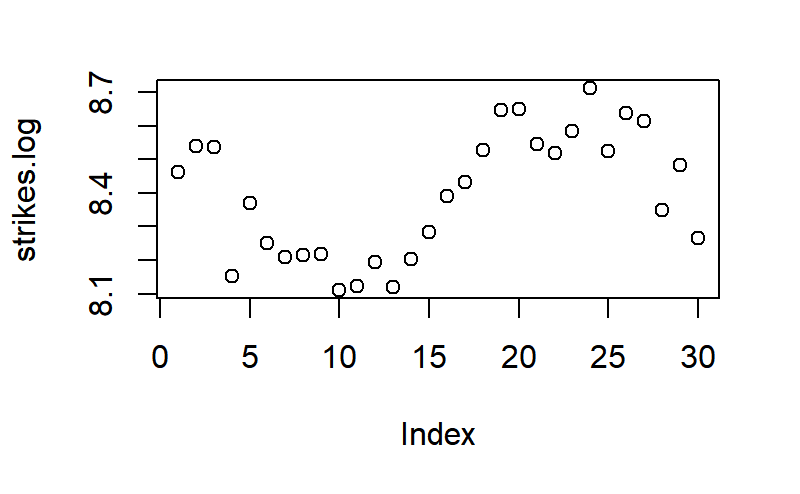

```r
library(forecast)
plot(strikes.log)
```

```r
adf.test(strikes.log)
```

```
    Augmented Dickey-Fuller Test

data:  strikes.log
Dickey-Fuller = -1.0553, Lag order = 3, p-value
= 0.9138
alternative hypothesis: stationary
```

Since p > 0.05, we do not reject the null hypothesis. The time series is not stationary.

```r
strikes.log_diff = diff(strikes.log)
adf.test(strikes.log_diff)
```

```
    Augmented Dickey-Fuller Test

data:  strikes.log_diff
Dickey-Fuller = -1.0583, Lag order = 3, p-value
= 0.913
alternative hypothesis: stationary
```

The p value is still greater than 0.05 so it is not stationary.

```r
strikes.log_diff2 = diff(strikes.log_diff)
adf.test(strikes.log_diff2)
```

```
    Augmented Dickey-Fuller Test

data:  strikes.log_diff2
Dickey-Fuller = -3.9582, Lag order = 3, p-value
= 0.02429
alternative hypothesis: stationary
```

Since p < 0.05, the time series is now stationary.

```r
Box.test(strikes.log_diff2, type = "Ljung")
```

```
    Box-Ljung test

data:  strikes.log_diff2
X-squared = 11.864, df = 1, p-value = 0.0005722
```

Since p < 0.05, we reject the null hypothesis. The time series is autocorrelated.

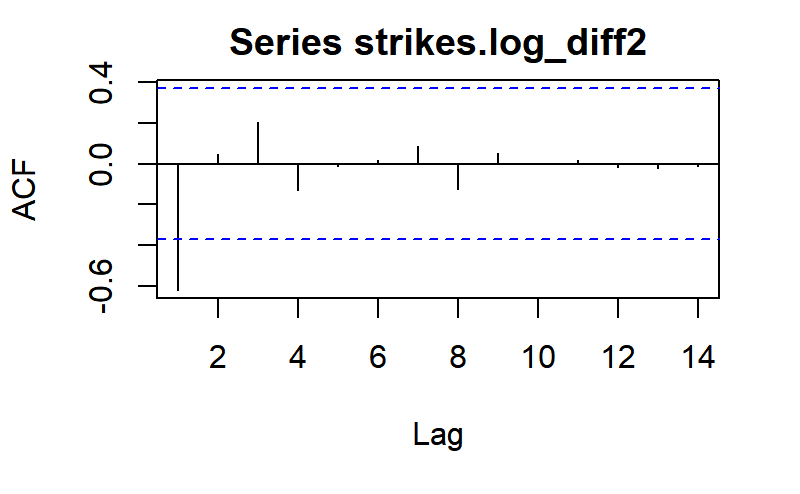

```r
acf(strikes.log_diff2) #MA(1)
```

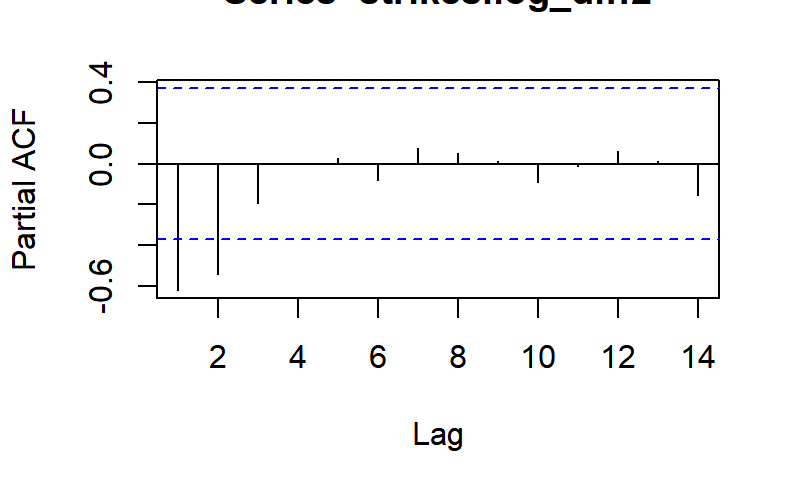

```r
pacf(strikes.log_diff2) # AR(2)
```

```r
ma1 = Arima(strikes.log_diff2, order = c(0,0,1))
ar2 = Arima(strikes.log_diff2, order = c(2,0,0))
arma21 = Arima(strikes.log_diff2, order = c(2,0,1))
```

```r
ma1
```

```
Series: strikes.log_diff2
ARIMA(0,0,1) with non-zero mean

Coefficients:
        ma1    mean
      -1.00  -5e-04
s.e.   0.13   3e-03

sigma^2 = 0.01939:  log likelihood = 14.83
AIC=-23.65   AICc=-22.65   BIC=-19.66
```

```r
ar2
```

```
Series: strikes.log_diff2
ARIMA(2,0,0) with non-zero mean

Coefficients:
          ar1      ar2     mean
      -1.1397  -0.7796  -0.0006
s.e.   0.1355   0.1371   0.0079

sigma^2 = 0.01557:  log likelihood = 18.93
AIC=-29.87   AICc=-28.13   BIC=-24.54
```

```r
arma21
```

```
Series: strikes.log_diff2
ARIMA(2,0,1) with non-zero mean

Coefficients:
          ar1      ar2      ma1     mean
      -0.9772  -0.6551  -0.3050  -0.0005
s.e.   0.2325   0.2214   0.2845   0.0061

sigma^2 = 0.01569:  log likelihood = 19.47
AIC=-28.93   AICc=-26.21   BIC=-22.27
```

Snce AR(2) has the lowest AIC, BIC, and AICc, we select AR(2) as the best fitting model.

```r
ar2.d = Arima(strikes.log, order = c(2,2,0))
```

The order has middle index, 2 because we differenced twice.

```r
ar2.d
```

```
Series: strikes.log
ARIMA(2,2,0)

Coefficients:
          ar1      ar2
      -1.1401  -0.7800
s.e.   0.1354   0.1368

sigma^2 = 0.01497:  log likelihood = 18.93
AIC=-31.86   AICc=-30.86   BIC=-27.87
```

```r
ar2 = Arima(strikes.log_diff2, order = c(2,0,0), include.mean = F) # we indicate mean zero
ar2
```

```
Series: strikes.log_diff2
ARIMA(2,0,0) with zero mean

Coefficients:
          ar1      ar2
      -1.1401  -0.7800
s.e.   0.1354   0.1368

sigma^2 = 0.01497:  log likelihood = 18.93
AIC=-31.86   AICc=-30.86   BIC=-27.87
```

For phi_2, we have the interval -0.78 +- 1.96(0.1368) or (-1.048, -0.51187). The interval does not include zero so the coefficient is significant.

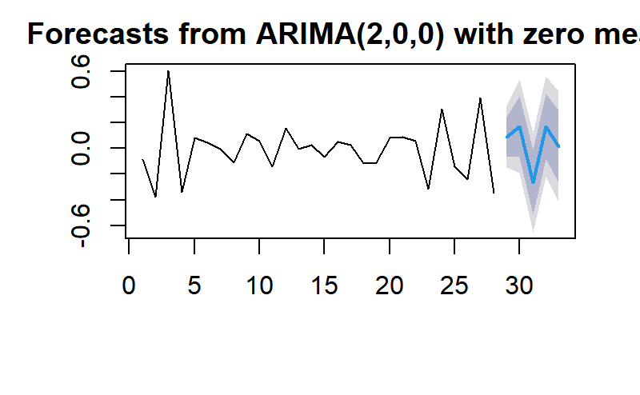

```r
plot(forecast(ar2, h = 5))
```

Forecast of the original data

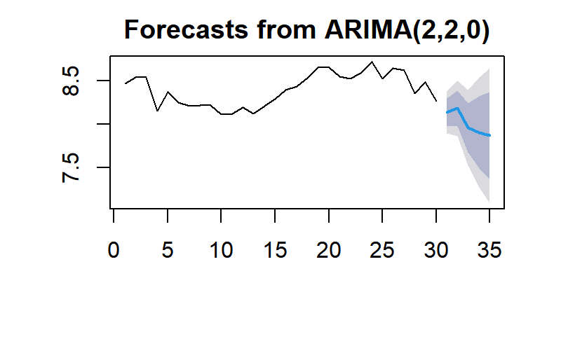

```r
plot(forecast(ar2.d, h = 5))
```

[figure not shown]

```r
tsdiag(ar2.d)
```

Seasonal Models

```r
air = AirPassengers
air
```

```
     Jan Feb Mar Apr May Jun Jul Aug Sep
1949 112 118 132 129 121 135 148 148 136
1950 115 126 141 135 125 149 170 170 158
1951 145 150 178 163 172 178 199 199 184
1952 171 180 193 181 183 218 230 242 209
1953 196 196 236 235 229 243 264 272 237
1954 204 188 235 227 234 264 302 293 259
1955 242 233 267 269 270 315 364 347 312
1956 284 277 317 313 318 374 413 405 355
1957 315 301 356 348 355 422 465 467 404
1958 340 318 362 348 363 435 491 505 404
1959 360 342 406 396 420 472 548 559 463
1960 417 391 419 461 472 535 622 606 508
     Oct Nov Dec
1949 119 104 118
1950 133 114 140
1951 162 146 166
1952 191 172 194
1953 211 180 201
1954 229 203 229
1955 274 237 278
1956 306 271 306
1957 347 305 336
1958 359 310 337
1959 407 362 405
1960 461 390 432
```

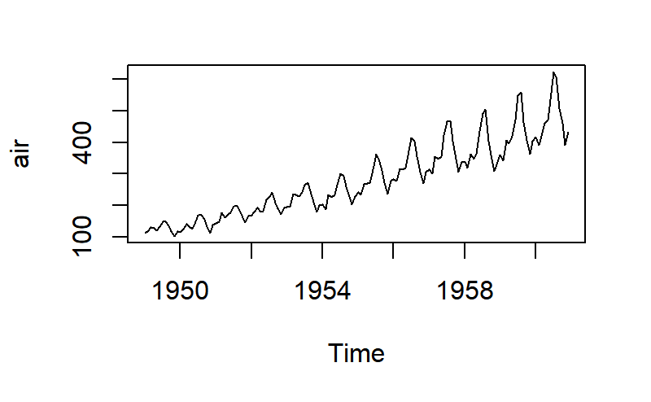

```r
plot(air)
```

The data has seasonality and follows a trend.

```r
adf.test(air)
```

```
    Augmented Dickey-Fuller Test

data:  air
Dickey-Fuller = -7.3186, Lag order =
5, p-value = 0.01
alternative hypothesis: stationary
```

The adf test doesn’t work with seasonal data.

```r
air.l = log(air)
air.l.d = diff(air.l)
```

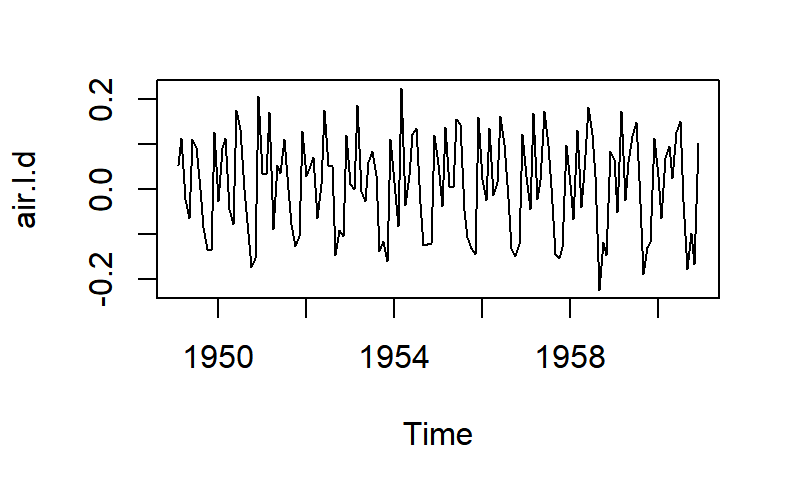

```r
plot(air.l.d)
```

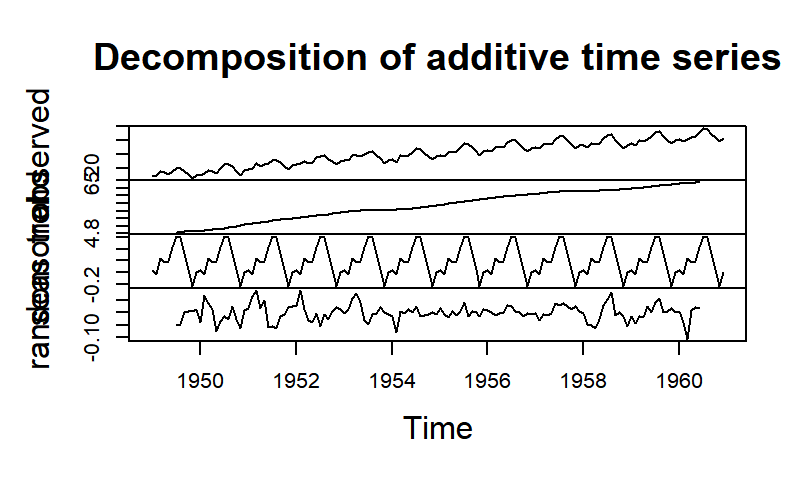

```r
plot(decompose(air.l))
```

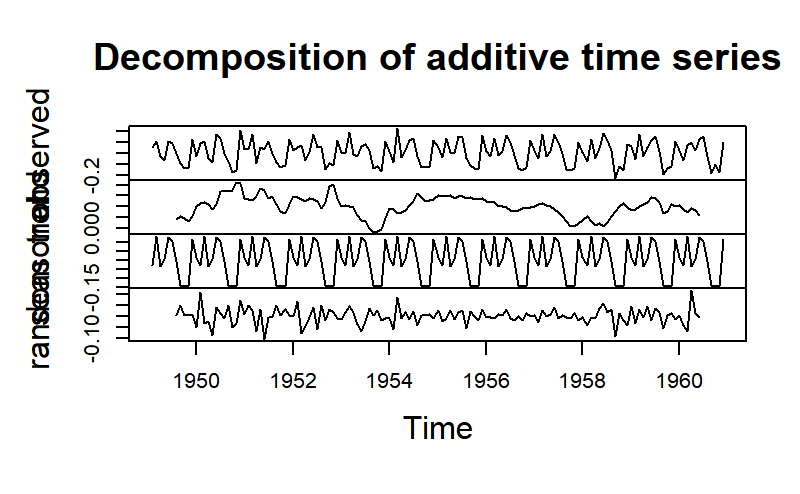

```r
plot(decompose(air.l.d))
```

```r
Box.test(air.l.d, type = "Ljung")
```

```
    Box-Ljung test

data:  air.l.d
X-squared = 5.8263, df = 1, p-value = 0.01579
```

The time series is autocorrelated.

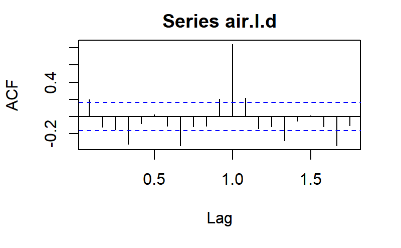

```r
acf(air.l.d)
```

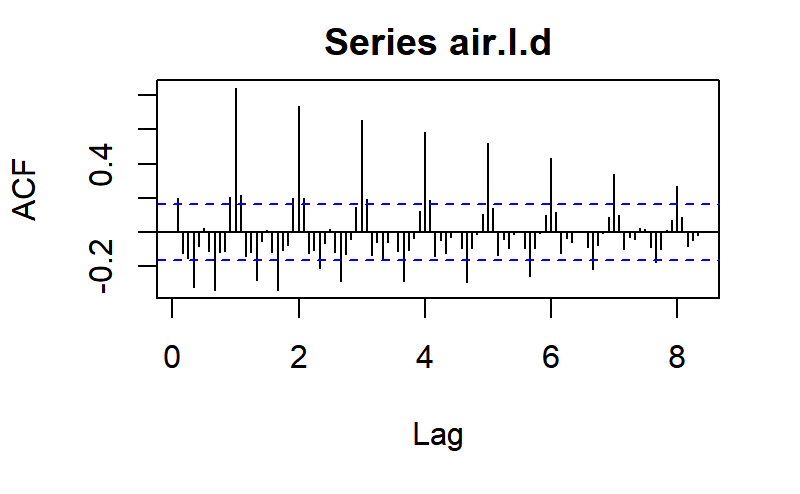

```r
acf(air.l.d, lag = 100)
```

Every twelve months, the ACF is significant.

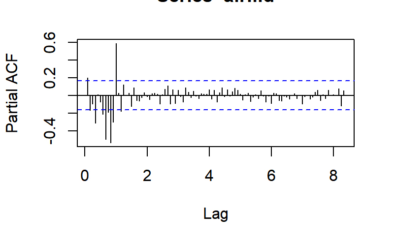

```r
pacf(air.l.d, lag = 100)
```

The PACF cuts off at 12. The ACF cuts off at 12, 24, 36, …

We have an ARMA(1,0)_12 model.

We do seasonal differencing.

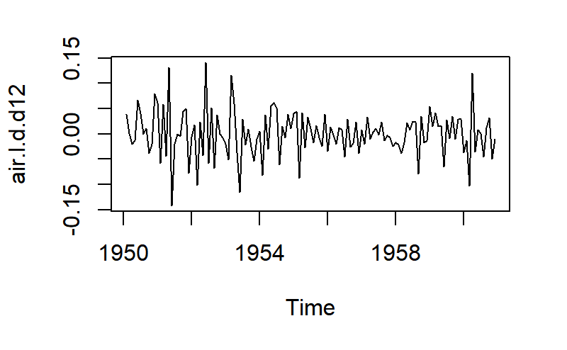

```r
air.l.d.d12 = diff(air.l.d, 12)
plot(air.l.d.d12)
```

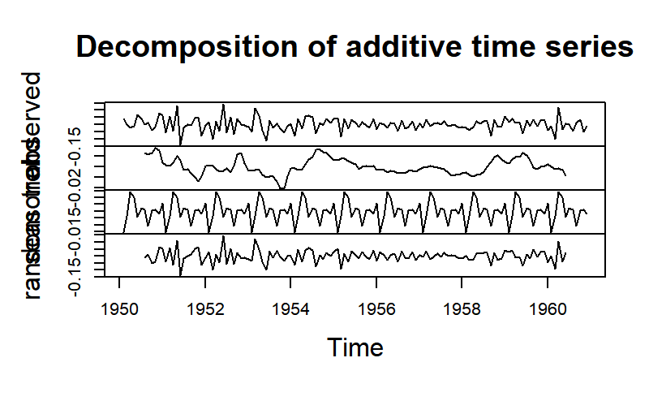

```r
plot(decompose(air.l.d.d12))
```

We have sARIMA( ,1, ) x (1,1,0)_12

We find the non-seasonal components.

We test out AR(1), MA(1), ARMA(1,1)

```r
sarima.ar1 = Arima(air.l, order = c(1,1,0), seasonal = list(order = c(1,1,0), period= 12))
sarima.ar1
```

```
Series: air.l
ARIMA(1,1,0)(1,1,0)[12]

Coefficients:
          ar1     sar1
      -0.3745  -0.4637
s.e.   0.0808   0.0808

sigma^2 = 0.001482:  log likelihood = 240.41
AIC=-474.82   AICc=-474.63   BIC=-466.19
```

```r
sarima.arma1 = Arima(air.l, order = c(1,1,1), seasonal = list(order = c(1,1,0), period= 12))
sarima.arma1
```

```
Series: air.l
ARIMA(1,1,1)(1,1,0)[12]

Coefficients:
         ar1      ma1     sar1
      0.0547  -0.4886  -0.4731
s.e.  0.2161   0.1933   0.0800

sigma^2 = 0.001461:  log likelihood = 241.73
AIC=-475.47   AICc=-475.15   BIC=-463.97
```

```r
sarima.ma1 = Arima(air.l, order = c(0,1,1), seasonal = list(order = c(1,1,0), period= 12))
sarima.ma1
```

```
Series: air.l
ARIMA(0,1,1)(1,1,0)[12]

Coefficients:
          ma1     sar1
      -0.4423  -0.4743
s.e.   0.0832   0.0798

sigma^2 = 0.00145:  log likelihood = 241.7
AIC=-477.41   AICc=-477.22   BIC=-468.78
```

We select MA(1) as it has the lowest criterion.

Final model is sARIMA(0,1,1) X (1,1,0)_12.

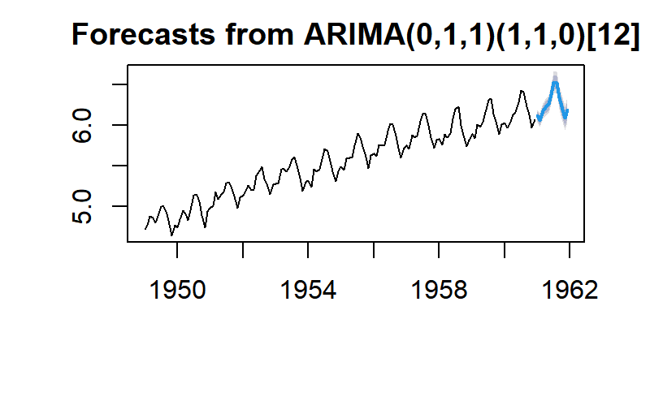

```r
plot(forecast(sarima.ma1, h = 12))
```

```r
air.f = forecast(sarima.ma1, h = 12)
air.f
```

|  | Point Forecast | Lo 80 | Hi 80 | Lo 95 | Hi 95 |
| --- | --- | --- | --- | --- | --- |
| Jan 1961 | 6.117909 | 6.069105 | 6.166714 | 6.043269 | 6.192549 |
| Feb 1961 | 6.059737 | 6.003856 | 6.115617 | 5.974275 | 6.145198 |
| Mar 1961 | 6.177458 | 6.115302 | 6.239614 | 6.082399 | 6.272518 |
| Apr 1961 | 6.215849 | 6.147995 | 6.283702 | 6.112076 | 6.319622 |
| May 1961 | 6.256153 | 6.183045 | 6.329262 | 6.144343 | 6.367963 |
| Jun 1961 | 6.377379 | 6.299369 | 6.455389 | 6.258073 | 6.496686 |
| Jul 1961 | 6.527399 | 6.444778 | 6.610021 | 6.401041 | 6.653758 |
| Aug 1961 | 6.523126 | 6.436137 | 6.610115 | 6.390088 | 6.656164 |
| Sep 1961 | 6.341024 | 6.249877 | 6.432172 | 6.201627 | 6.480422 |
| Oct 1961 | 6.228844 | 6.133720 | 6.323968 | 6.083364 | 6.374323 |

[output cut: 2 more lines]

```r
air.f$mean
```

```
          Jan      Feb      Mar      Apr      May
1961 6.117909 6.059737 6.177458 6.215849 6.256153
          Jun      Jul      Aug      Sep      Oct
1961 6.377379 6.527399 6.523126 6.341024 6.228844
          Nov      Dec
1961 6.085347 6.192351
```

```r
preds = exp(air.f$mean)
preds
```

```
          Jan      Feb      Mar      Apr      May
1961 453.9146 428.2627 481.7659 500.6207 521.2100
          Jun      Jul      Aug      Sep      Oct
1961 588.3837 683.6181 680.7028 567.3772 507.1688
          Nov      Dec
1961 439.3720 488.9945
```

```r
air_preds = ts(c(air, preds), start = c(1949, 1), frequency = 12)
```

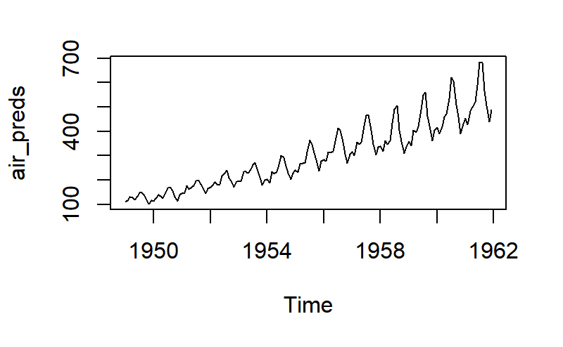

```r
plot(air_preds)
```

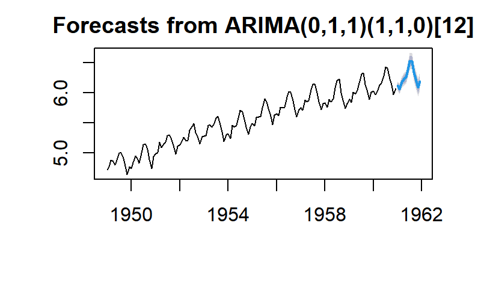

```r
plot(forecast(sarima.ma1, h = 12))
```